# F9_03_ORG_MISSION_PURPOSE

Organization mission · Text report

## Overview

**Description**

Mission description

**Table**

`F9-P03-T00-MISSION` (one)

**Location code**

`F990-PC-PART-03-LINE-01`, `F990-EZ-PART-03-LINE-00`

**Family**

`F990-PC-PART-03-LINE-01`

**Data type**

text (xsd: ShortExplanationType)

**Scope**

PZ

**Status**

unreviewed

8

xpaths mapped (4 observed)

5,973,091

filings with a value

2009–2024

tax years observed

4

open flags (0 errors)

## Flags

| Severity | Flag | Xpath | Detail |
| --- | --- | --- | --- |
| ⓘ info | `UNOBSERVED` | IRS990/Form990PartIII/MissionDescription | never observed in TY2009-2024 filings |
| ⓘ info | `UNOBSERVED` | IRS990/PrimaryExemptPurpose | never observed in TY2009-2024 filings |
| ⓘ info | `UNOBSERVED` | IRS990EZ/MissionDesc | never observed in TY2009-2024 filings |
| ⓘ info | `UNOBSERVED` | IRS990EZ/MissionDescription | never observed in TY2009-2024 filings |

## Xpaths

All mapped xpaths (under /Return/ReturnData or /Return/ReturnHeader), oldest first. Charts label each series by its xpath.

| Xpath | Form | First year | Last year | Versions | Filings | Repeats in |
| --- | --- | --- | --- | --- | --- | --- |
| IRS990/MissionDescription | 990 | 2009 | 2012 | 19 | 494,531 | 0.0% |
| IRS990EZ/PrimaryExemptPurpose | 990-EZ | 2009 | 2012 | 18 | 254,594 | 0.0% |
| IRS990/MissionDesc | 990 | 2013 | 2024 | 38 | 3,342,665 | 0.0% |
| IRS990EZ/PrimaryExemptPurposeTxt | 990-EZ | 2013 | 2024 | 38 | 1,881,301 | 0.0% |
| IRS990/Form990PartIII/MissionDescription | 990 |  |  |  | 0 |  |
| IRS990/PrimaryExemptPurpose | 990 |  |  |  | 0 |  |
| IRS990EZ/MissionDesc | 990-EZ |  |  |  | 0 |  |
| IRS990EZ/MissionDescription | 990-EZ |  |  |  | 0 |  |

## Coverage

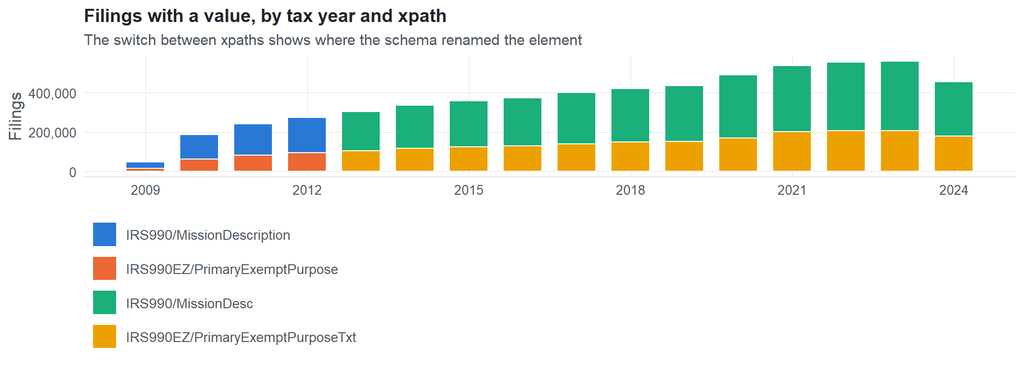

**Table view**

Table view: filings by tax year and series

| Tax year | IRS990/MissionDescription | IRS990EZ/PrimaryExemptPurpose | IRS990/MissionDesc | IRS990EZ/PrimaryExemptPurposeTxt |
| --- | --- | --- | --- | --- |
| 2009 | 32,718 | 15,470 | 0 | 0 |
| 2010 | 122,862 | 63,326 | 0 | 0 |
| 2011 | 159,395 | 82,048 | 0 | 0 |
| 2012 | 179,556 | 93,750 | 0 | 0 |
| 2013 | 0 | 0 | 198,699 | 104,375 |
| 2014 | 0 | 0 | 218,466 | 116,417 |
| 2015 | 0 | 0 | 233,238 | 124,894 |
| 2016 | 0 | 0 | 243,570 | 130,484 |
| 2017 | 0 | 0 | 261,211 | 139,145 |
| 2018 | 0 | 0 | 270,964 | 149,384 |
| 2019 | 0 | 0 | 283,097 | 152,623 |
| 2020 | 0 | 0 | 319,455 | 169,865 |
| 2021 | 0 | 0 | 335,581 | 202,729 |
| 2022 | 0 | 0 | 348,147 | 206,135 |
| 2023 | 0 | 0 | 353,813 | 206,382 |
| 2024 | 0 | 0 | 276,424 | 178,868 |

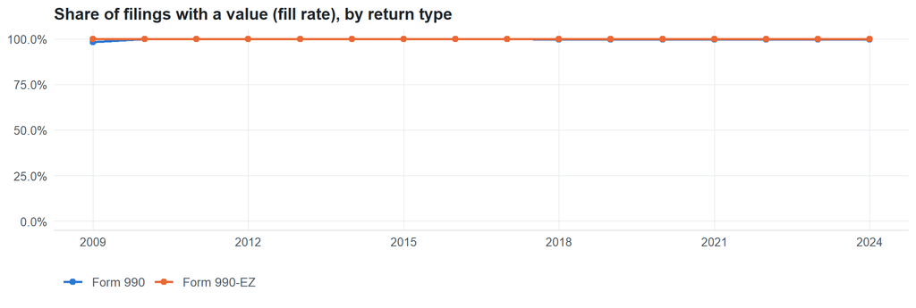

**Table view**

Table view: fill rate

| Tax year | Return type | Filings | All filings | Fill rate |
| --- | --- | --- | --- | --- |
| 2009 | Form 990 | 32,718 | 33,311 | 98.22% |
| 2009 | Form 990-EZ | 15,470 | 15,470 | 100.00% |
| 2010 | Form 990 | 122,862 | 123,025 | 99.87% |
| 2010 | Form 990-EZ | 63,326 | 63,326 | 100.00% |
| 2011 | Form 990 | 159,395 | 159,504 | 99.93% |
| 2011 | Form 990-EZ | 82,048 | 82,048 | 100.00% |
| 2012 | Form 990 | 179,556 | 179,688 | 99.93% |
| 2012 | Form 990-EZ | 93,750 | 93,750 | 100.00% |
| 2013 | Form 990 | 198,699 | 198,855 | 99.92% |
| 2013 | Form 990-EZ | 104,375 | 104,375 | 100.00% |
| 2014 | Form 990 | 218,466 | 218,619 | 99.93% |
| 2014 | Form 990-EZ | 116,417 | 116,417 | 100.00% |
| 2015 | Form 990 | 233,238 | 233,519 | 99.88% |
| 2015 | Form 990-EZ | 124,894 | 124,894 | 100.00% |
| 2016 | Form 990 | 243,570 | 243,903 | 99.86% |
| 2016 | Form 990-EZ | 130,484 | 130,484 | 100.00% |
| 2017 | Form 990 | 261,211 | 261,612 | 99.85% |
| 2017 | Form 990-EZ | 139,144 | 139,144 | 100.00% |
| 2018 | Form 990 | 270,964 | 271,442 | 99.82% |
| 2018 | Form 990-EZ | 149,384 | 149,384 | 100.00% |
| 2019 | Form 990 | 283,097 | 283,694 | 99.79% |
| 2019 | Form 990-EZ | 152,622 | 152,622 | 100.00% |
| 2020 | Form 990 | 319,454 | 320,342 | 99.72% |
| 2020 | Form 990-EZ | 169,864 | 169,864 | 100.00% |
| 2021 | Form 990 | 335,573 | 336,480 | 99.73% |
| 2021 | Form 990-EZ | 202,724 | 202,724 | 100.00% |
| 2022 | Form 990 | 348,140 | 349,055 | 99.74% |
| 2022 | Form 990-EZ | 206,130 | 206,130 | 100.00% |
| 2023 | Form 990 | 353,807 | 354,768 | 99.73% |
| 2023 | Form 990-EZ | 206,379 | 206,379 | 100.00% |
| 2024 | Form 990 | 276,420 | 277,298 | 99.68% |
| 2024 | Form 990-EZ | 178,867 | 178,867 | 100.00% |

## Values

| Result | Check | Detail |
| --- | --- | --- |
| ✓ pass | Values are text, not numbers | 0% of values are numeric |
| ✓ pass | No dominant boilerplate value | most common value covers 1% of filings: “NONE” |
| ⓘ info | No sign of truncation | IRS990/MissionDesc: longest value is exactly 1000 characters; IRS990/MissionDescription: longest value is exactly 1000 characters; IRS990EZ/PrimaryExemptPurpose: longest value is exactly 1000 characte… |

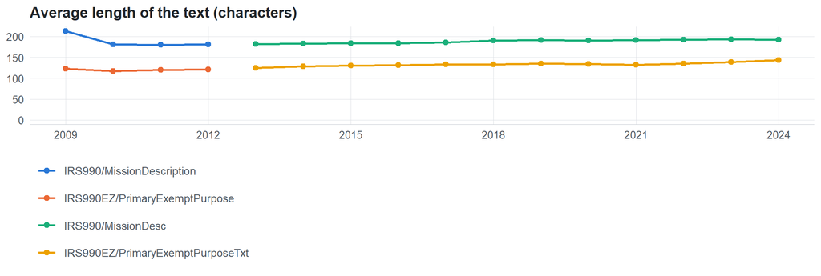

**Table view**

Table view: length and variety by tax year

| Series | Tax year | Filings | Avg length | Max length | Distinct values (approx.) |
| --- | --- | --- | --- | --- | --- |
| IRS990/MissionDescription | 2009 | 32,718 | 213 | 1,000 | 27,990 |
| IRS990/MissionDescription | 2010 | 122,862 | 181 | 1,000 | 54,561 |
| IRS990/MissionDescription | 2011 | 159,395 | 180 | 1,000 | 114,172 |
| IRS990/MissionDescription | 2012 | 179,556 | 181 | 1,000 | 101,726 |
| IRS990EZ/PrimaryExemptPurpose | 2009 | 15,470 | 123 | 1,000 | 5,534 |
| IRS990EZ/PrimaryExemptPurpose | 2010 | 63,326 | 117 | 1,000 | 27,889 |
| IRS990EZ/PrimaryExemptPurpose | 2011 | 82,048 | 120 | 1,000 | 57,749 |
| IRS990EZ/PrimaryExemptPurpose | 2012 | 93,750 | 121 | 1,000 | 39,436 |
| IRS990/MissionDesc | 2013 | 198,699 | 182 | 1,000 | 78,746 |
| IRS990/MissionDesc | 2014 | 218,466 | 183 | 1,000 | 154,537 |
| IRS990/MissionDesc | 2015 | 233,238 | 184 | 1,000 | 134,656 |
| IRS990/MissionDesc | 2016 | 243,570 | 184 | 1,000 | 178,137 |
| IRS990/MissionDesc | 2017 | 261,211 | 186 | 1,000 | 163,061 |
| IRS990/MissionDesc | 2018 | 270,964 | 191 | 1,000 | 223,662 |
| IRS990/MissionDesc | 2019 | 283,097 | 192 | 1,000 | 148,721 |
| IRS990/MissionDesc | 2020 | 319,455 | 191 | 1,000 | 151,042 |
| IRS990/MissionDesc | 2021 | 335,581 | 191 | 1,000 | 150,338 |
| IRS990/MissionDesc | 2022 | 348,147 | 192 | 1,000 | 340,009 |
| IRS990/MissionDesc | 2023 | 353,813 | 193 | 1,000 | 114,037 |
| IRS990/MissionDesc | 2024 | 276,424 | 192 | 1,000 | 121,630 |
| IRS990EZ/PrimaryExemptPurposeTxt | 2013 | 104,375 | 125 | 1,000 | 47,067 |
| IRS990EZ/PrimaryExemptPurposeTxt | 2014 | 116,417 | 128 | 1,000 | 69,728 |
| IRS990EZ/PrimaryExemptPurposeTxt | 2015 | 124,894 | 130 | 1,000 | 65,997 |
| IRS990EZ/PrimaryExemptPurposeTxt | 2016 | 130,484 | 131 | 1,000 | 97,697 |
| IRS990EZ/PrimaryExemptPurposeTxt | 2017 | 139,145 | 133 | 1,000 | 66,561 |
| IRS990EZ/PrimaryExemptPurposeTxt | 2018 | 149,384 | 133 | 1,000 | 132,445 |
| IRS990EZ/PrimaryExemptPurposeTxt | 2019 | 152,623 | 135 | 1,000 | 70,942 |
| IRS990EZ/PrimaryExemptPurposeTxt | 2020 | 169,865 | 135 | 1,000 | 96,697 |
| IRS990EZ/PrimaryExemptPurposeTxt | 2021 | 202,729 | 132 | 1,000 | 103,604 |
| IRS990EZ/PrimaryExemptPurposeTxt | 2022 | 206,135 | 135 | 1,000 | 183,367 |
| IRS990EZ/PrimaryExemptPurposeTxt | 2023 | 206,382 | 139 | 1,000 | 81,841 |
| IRS990EZ/PrimaryExemptPurposeTxt | 2024 | 178,868 | 143 | 1,000 | 67,693 |

Most common values by xpath (all years; long values truncated)

| Series | Value | Filings | Share |
| --- | --- | --- | --- |
| IRS990/MissionDescription | NONE | 5,730 | 1.2% |
| IRS990/MissionDescription | SEE SCHEDULE O | 2,683 | 0.5% |
| IRS990/MissionDescription | None | 1,150 | 0.2% |
| IRS990/MissionDescription | SEE SCHEDULE O. | 688 | 0.1% |
| IRS990/MissionDescription | THE MISSION OF NATIONAL CHURCH RESIDENCES IS TO PROVIDE QUALITY HOUSING AND CARE AT AFFORDABLE PRICE | 564 | 0.1% |
| IRS990/MissionDescription | LABOR UNION | 530 | 0.1% |
| IRS990/MissionDescription | EDUCATION | 522 | 0.1% |
| IRS990/MissionDescription | See Schedule O | 478 | 0.1% |
| IRS990/MissionDescription | TO PROVIDE ACCESSIBLE HOUSING FOR ADULTS WITH DISABILITIES AND SENIORS. ALSO TO PROVIDE SUPPORTIVE C | 301 | 0.1% |
| IRS990/MissionDescription | Title Holding Corporation For Real Property | 196 | 0.0% |
| IRS990/MissionDescription | FRATERNAL ORGANIZATION | 102 | 0.0% |
| IRS990/MissionDescription | The organization’s mission is to nurture the healing ministry of the Church by bringing it new life, | 53 | 0.0% |
| IRS990/MissionDescription | The mission is to bring compassion to health care and to be good help to those in need, especially t | 31 | 0.0% |
| IRS990/MissionDescription | THE MISSION OF THE ORGANIZATION IS TO ENRICH THE LIVES OF OLDER ADULTS THROUGH SERVICE AND COMMUNITI | 30 | 0.0% |
| IRS990EZ/PrimaryExemptPurpose | EDUCATION | 963 | 0.4% |
| IRS990EZ/PrimaryExemptPurpose | SEE SCHEDULE O | 862 | 0.3% |
| IRS990EZ/PrimaryExemptPurpose | See Schedule O | 707 | 0.3% |
| IRS990EZ/PrimaryExemptPurpose | COMMUNITY SERVICE | 515 | 0.2% |
| IRS990EZ/PrimaryExemptPurpose | THE ORGANIZATION WAS ESTABLISHED TO FURTHER THE INTERESTS OF ITS MEMBERSHIP BY SEEKING IMPROVED TERM | 475 | 0.2% |
| IRS990EZ/PrimaryExemptPurpose | LABOR UNION | 424 | 0.2% |
| IRS990EZ/PrimaryExemptPurpose | Education | 337 | 0.1% |
| IRS990EZ/PrimaryExemptPurpose | SEE BELOW | 279 | 0.1% |
| IRS990EZ/PrimaryExemptPurpose | EDUCATIONAL | 250 | 0.1% |
| IRS990EZ/PrimaryExemptPurpose | AGRICULTURE PROMOTION | 225 | 0.1% |
| IRS990EZ/PrimaryExemptPurpose | CHILD ADVOCACY | 98 | 0.0% |
| IRS990EZ/PrimaryExemptPurpose | THE ORGANIZATION PROVIDES HOUSING FOR THE MENTALLY ILL. | 49 | 0.0% |
| IRS990EZ/PrimaryExemptPurpose | FRATERNAL ORGANIZATION | 25 | 0.0% |
| IRS990EZ/PrimaryExemptPurpose | LITTLE LEAGUE BASEBALL | 20 | 0.0% |
| IRS990/MissionDesc | SEE SCHEDULE O | 26,625 | 0.8% |
| IRS990/MissionDesc | NONE | 18,538 | 0.6% |

First rows shown.

## Examples

| Tax year | Return | Xpath | Organization | Value | Source |
| --- | --- | --- | --- | --- | --- |
| 2024 | 990 | IRS990/MissionDesc | OWL CREEK COUNTRY CLUB | TO PROVIDE RECREATIONAL SERVICES AND ENTERTAINMENT TO MEMBERS | [XML](https://gt990datalake-rawdata.s3.amazonaws.com/EfileData/XmlFiles/202513219349315726_public.xml) |
| 2024 | 990EZ | IRS990EZ/PrimaryExemptPurposeTxt | THE CREATIVES PROJECT INC | ARTS ED AND DEVELOPMENT | [XML](https://gt990datalake-rawdata.s3.amazonaws.com/EfileData/XmlFiles/202510859349201521_public.xml) |
| 2023 | 990 | IRS990/MissionDesc | ZEPF CENTER | MENTAL HEALTH RECOVERY SERVICES AND VOCATIONAL SERVICES | [XML](https://gt990datalake-rawdata.s3.amazonaws.com/EfileData/XmlFiles/202423399349300887_public.xml) |
| 2023 | 990EZ | IRS990EZ/PrimaryExemptPurposeTxt | GALBRAITH GRAVITY JUNIOR RACING | Develop youth mountain bike race skill by connecting riders aged 5-18 with world class coaches spons | [XML](https://gt990datalake-rawdata.s3.amazonaws.com/EfileData/XmlFiles/202422849349200002_public.xml) |
| 2022 | 990 | IRS990/MissionDesc | MERRILL COMMUNITY HOMELESS CENTER INC | TO PROVIDE SHELTER TO THE HOMELESS COMMUNITY IN MERRILL WI | [XML](https://gt990datalake-rawdata.s3.amazonaws.com/EfileData/XmlFiles/202331589349300003_public.xml) |
| 2022 | 990EZ | IRS990EZ/PrimaryExemptPurposeTxt | BEHIND CLOSED DOORS MINISTRIES | OPERATING CHURCH | [XML](https://gt990datalake-rawdata.s3.amazonaws.com/EfileData/XmlFiles/202311239349202216_public.xml) |
| 2021 | 990 | IRS990/MissionDesc | WEST TENNESSEE BUILDERS CARE FOUNDATION | TO LEVERAGE THE BUILDING INDUSTRY’S SPECIALIZED SKILLS TO HELP PROVIDE CONSTRUCTION EDUCATION AND SH | [XML](https://gt990datalake-rawdata.s3.amazonaws.com/EfileData/XmlFiles/202331329349301558_public.xml) |
| 2021 | 990EZ | IRS990EZ/PrimaryExemptPurposeTxt | CHRISTIAN CHURCHES TOGETHER IN THE USA INC | Christian Churches Together provides a context marked by prayer worship and fellowship in which chur | [XML](https://gt990datalake-rawdata.s3.amazonaws.com/EfileData/XmlFiles/202201369349206320_public.xml) |
| 2020 | 990 | IRS990/MissionDesc | SOCIAL JUSTICE PUBLIC CHARTER SCHOOL | TO PROVIDE A FREE PUBLIC EDUCATION TO MIDDLE SCHOOL STUDENTS IN GRADES FIVE THROUGH EIGHT. THE SCHOO | [XML](https://gt990datalake-rawdata.s3.amazonaws.com/EfileData/XmlFiles/202201309349304660_public.xml) |
| 2020 | 990EZ | IRS990EZ/PrimaryExemptPurposeTxt | GENESEE TOWNSHIP VETERANS MEMORIAL | BUILD AND MAINTAIN VETERANS MEMORIAL | [XML](https://gt990datalake-rawdata.s3.amazonaws.com/EfileData/XmlFiles/202142879349200014_public.xml) |
| 2019 | 990 | IRS990/MissionDesc | Chauffeurs Teamsters & Helpers Local 878 | Labor Union: Organizing, negotiating and providing benefits for members in securing fair wages and w | [XML](https://gt990datalake-rawdata.s3.amazonaws.com/EfileData/XmlFiles/202043219349315409_public.xml) |
| 2019 | 990EZ | IRS990EZ/PrimaryExemptPurposeTxt | CRESSKILL COUGARS UNITED SOCCER | TO FOSTER THE DEVELOPMENT OF CAMARADERIE, FELLOWSHIP AND SKILLS RELATED TO SOCCER. | [XML](https://gt990datalake-rawdata.s3.amazonaws.com/EfileData/XmlFiles/202013089349200306_public.xml) |

## Reviewer checklist

- The definition matches the form line and instructions for every xpath’s schema years.
- Every xpath pooled here measures the same thing on the 990 and 990-EZ (close enough for analysis).
- The coverage chart has no unexplained gaps or jumps between tax years.
- Each open flag is fixed, or accepted with a note in validation_log.csv.
- Values answer the question on the form line (not another line’s explanation).
- Boilerplate such as ‘See Schedule O’ or ‘N/A’ is expected here, or should be treated as missing.
- Text that is really a number or a code is flagged for a different data type.

Record the review as a row in `inst/extdata/src/validation_log.csv` (variable_name, reviewer, date, status, note). Evidence built 2026-09-23 17:09:04 MST from the ef2 DuckDB builds, TY2009–2024.